# TASK-5: Credit Card Fraud Detection

Kankana Ghosh

2023-07-22

Importing all the necessary libraries required for the analysis

```r
rm(list=ls())
set.seed(987654321)
library(tidyverse)
library(Metrics)
library(dplyr)
library(randomForest)
df=read.csv("C:/Users/Kankana Ghosh/Desktop/Codsoft/creditcard.csv")
class(df)
```

```
## [1] "data.frame"
```

```r
str(df)
```

```
## 'data.frame':    284807 obs. of  31 variables:
##  $ Time  : num  0 0 1 1 2 2 4 7 7 9 ...
##  $ V1    : num  -1.36 1.192 -1.358 -0.966 -1.158 ...
##  $ V2    : num  -0.0728 0.2662 -1.3402 -0.1852 0.8777 ...
##  $ V3    : num  2.536 0.166 1.773 1.793 1.549 ...
##  $ V4    : num  1.378 0.448 0.38 -0.863 0.403 ...
##  $ V5    : num  -0.3383 0.06 -0.5032 -0.0103 -0.4072 ...
##  $ V6    : num  0.4624 -0.0824 1.8005 1.2472 0.0959 ...
##  $ V7    : num  0.2396 -0.0788 0.7915 0.2376 0.5929 ...
##  $ V8    : num  0.0987 0.0851 0.2477 0.3774 -0.2705 ...
##  $ V9    : num  0.364 -0.255 -1.515 -1.387 0.818 ...
##  $ V10   : num  0.0908 -0.167 0.2076 -0.055 0.7531 ...
##  $ V11   : num  -0.552 1.613 0.625 -0.226 -0.823 ...
##  $ V12   : num  -0.6178 1.0652 0.0661 0.1782 0.5382 ...
##  $ V13   : num  -0.991 0.489 0.717 0.508 1.346 ...
```

[output cut: 17 more lines]

```r
dim(df)
```

```
## [1] 284807     31
```

**Comment:** The dataset is dataframe in nature containig 284807 observations on 31 variables.

```r
fraud=sum(ifelse(df$Class==1,1,0))/nrow(df)
print(paste(round(fraud*100,2), "is the percentage of fraud cases in the given dataset"))
```

```
## [1] "0.17 is the percentage of fraud cases in the given dataset"
```

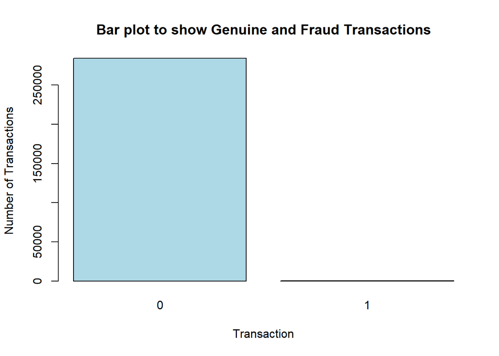

```r
no.of.frauds=fraud*nrow(df)
no.of.genuine.transaction=nrow(df)-fraud*nrow(df)
barplot(table(df$Class),main="Bar plot to show Genuine and Fraud Transactions",width=0.1,col="lightblue",xlab="Transaction", ylab="Number of Transactions")
```

```r
print(paste("There are",no.of.genuine.transaction," number of genuine transactions and",no.of.frauds," number of fraud transactions."))
```

```
## [1] "There are 284315  number of genuine transactions and 492  number of fraud transactions."
```

**Comments:** The barplot shows the number of genuine (0) and fraud (1) transaction done.

```r
s=sample(c(TRUE,FALSE),nrow(df),replace = TRUE,c(0.8,0.2))
train=df[s,]
test=df[!s,]

model=glm(Class~.,data=train,family=binomial(link="logit"))
summary(model)
```

```
##
## Call:
## glm(formula = Class ~ ., family = binomial(link = "logit"), data = train)
##
## Deviance Residuals:
##     Min       1Q   Median       3Q      Max
## -4.7789  -0.0287  -0.0185  -0.0110   4.5892
##
## Coefficients:
##               Estimate Std. Error z value Pr(>|z|)
## (Intercept) -8.492e+00  2.945e-01 -28.839  < 2e-16 ***
## Time        -4.463e-06  2.603e-06  -1.715 0.086399 .
## V1           9.054e-02  4.838e-02   1.871 0.061292 .
## V2           4.053e-02  7.186e-02   0.564 0.572726
## V3           5.766e-03  6.240e-02   0.092 0.926374
## V4           7.315e-01  9.614e-02   7.609 2.77e-14 ***
## V5           1.419e-01  8.250e-02   1.720 0.085384 .
## V6          -1.342e-01  8.594e-02  -1.562 0.118301
## V7          -4.752e-02  8.095e-02  -0.587 0.557157
## V8          -1.741e-01  3.537e-02  -4.922 8.58e-07 ***
## V9          -2.599e-01  1.428e-01  -1.819 0.068843 .
## V10         -9.044e-01  1.203e-01  -7.518 5.56e-14 ***
## V11         -1.203e-02  9.539e-02  -0.126 0.899605
## V12          2.457e-01  1.080e-01   2.275 0.022894 *
## V13         -3.730e-01  9.787e-02  -3.811 0.000138 ***
## V14         -6.029e-01  7.529e-02  -8.008 1.17e-15 ***
## V15         -7.472e-02  9.998e-02  -0.747 0.454892
## V16         -9.067e-02  1.649e-01  -0.550 0.582368
## V17         -1.020e-01  8.527e-02  -1.196 0.231830
## V18          8.875e-03  1.676e-01   0.053 0.957777
## V19          1.421e-01  1.213e-01   1.172 0.241277
## V20         -4.644e-01  9.363e-02  -4.960 7.06e-07 ***
## V21          4.125e-01  7.101e-02   5.809 6.29e-09 ***
## V22          6.520e-01  1.581e-01   4.124 3.72e-05 ***
## V23         -7.016e-02  6.650e-02  -1.055 0.291402
## V24          2.488e-01  1.718e-01   1.448 0.147585
## V25         -6.011e-02  1.512e-01  -0.397 0.691013
## V26          2.676e-01  2.128e-01   1.258 0.208547
## V27         -8.400e-01  1.374e-01  -6.112 9.84e-10 ***
## V28         -3.547e-01  1.004e-01  -3.534 0.000409 ***
## Amount       9.729e-04  4.086e-04   2.381 0.017258 *
## ---
## Signif. codes:  0 '***' 0.001 '**' 0.01 '*' 0.05 '.' 0.1 ' ' 1
##
## (Dispersion parameter for binomial family taken to be 1)
##
##     Null deviance: 5646.7  on 228022  degrees of freedom
## Residual deviance: 1712.4  on 227992  degrees of freedom
## AIC: 1774.4
##
## Number of Fisher Scoring iterations: 12
```

**Comments:** Now, splitting the dataset into train and test dataset in 80:20 ratio. Here the response variable is Class and predictors are all the other variables. After splitting the dataset applying logistic regression on the training data.

```r
pred=predict(model,newdata = test,type="response")
predicted=ifelse(pred>=0.5,1,0)
contingency.table=table(test$Class,predicted)
contingency.table
```

```
##    predicted
##         0     1
##   0 56664    10
##   1    45    65
```

```r
test.mse=mean(sum((test$Class-predicted)**2))
test.mse
```

```
## [1] 55
```

```r
accuracy=sum(diag(contingency.table))/sum(contingency.table)
accuracy
```

```
## [1] 0.9990314
```

**Comments:** Now, using the test data I validate the model.The test mse is less and the accuracy of the model is 99.90% implying that the model is a good model.

```r
Metrics::recall(test$Class,predicted)
```

```
## [1] 0.5909091
```

```r
Metrics::precision(test$Class,predicted)
```

```
## [1] 0.8666667
```

```r
Metrics::f1(test$Class,predicted)
```

```
## [1] 1
```

The precision of the model is 0.87 which is the proportion of observations predicted to be in the positive class (fraud) actually belongs to the positive class.

```r
rf_classifier= randomForest(Class~.,data=train,ntree=5)
rf_classifier
```

```
##
## Call:
##  randomForest(formula = Class ~ ., data = train, ntree = 5)
##                Type of random forest: regression
##                      Number of trees: 5
## No. of variables tried at each split: 10
##
##           Mean of squared residuals: 0.0007167729
##                     % Var explained: 57.14
```

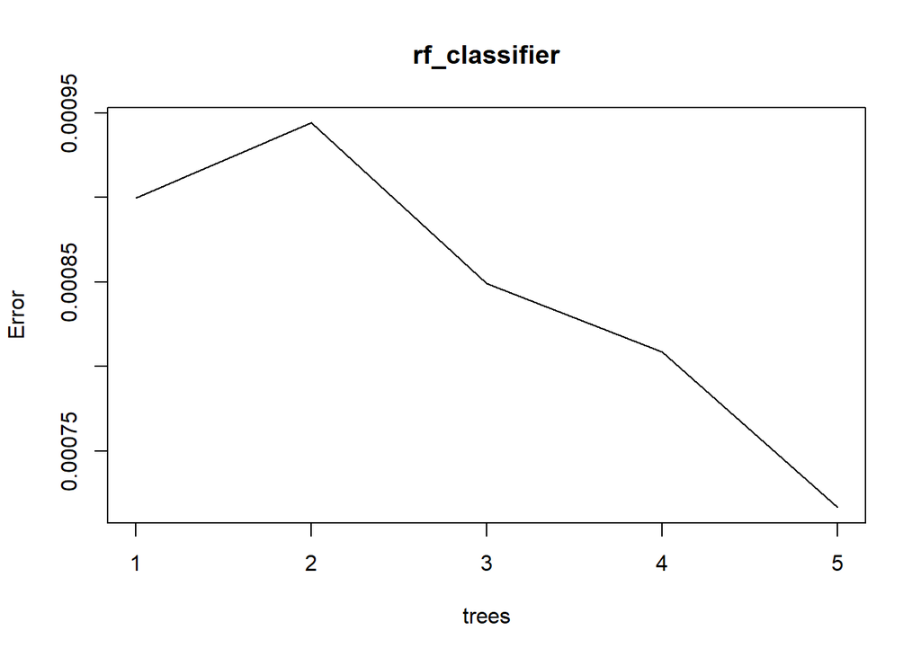

```r
plot(rf_classifier)
```

```r
importance(rf_classifier)
```

```
##        IncNodePurity
## Time        5.811873
## V1          3.128059
## V2          2.074140
## V3          6.642810
## V4         12.496292
## V5          2.486629
## V6          1.446155
## V7         11.479275
## V8          2.348852
## V9          7.785870
## V10        13.819318
## V11        59.490350
## V12        57.115234
## V13         5.539326
## V14        46.719599
## V15         3.291476
## V16        50.815644
## V17        38.015612
## V18         2.974914
## V19         2.143280
## V20         5.383414
## V21         2.964685
## V22         2.306784
## V23         1.395896
## V24         1.689463
## V25         2.615787
## V26        12.287665
## V27         3.061465
## V28         2.837549
## Amount      3.691825
```

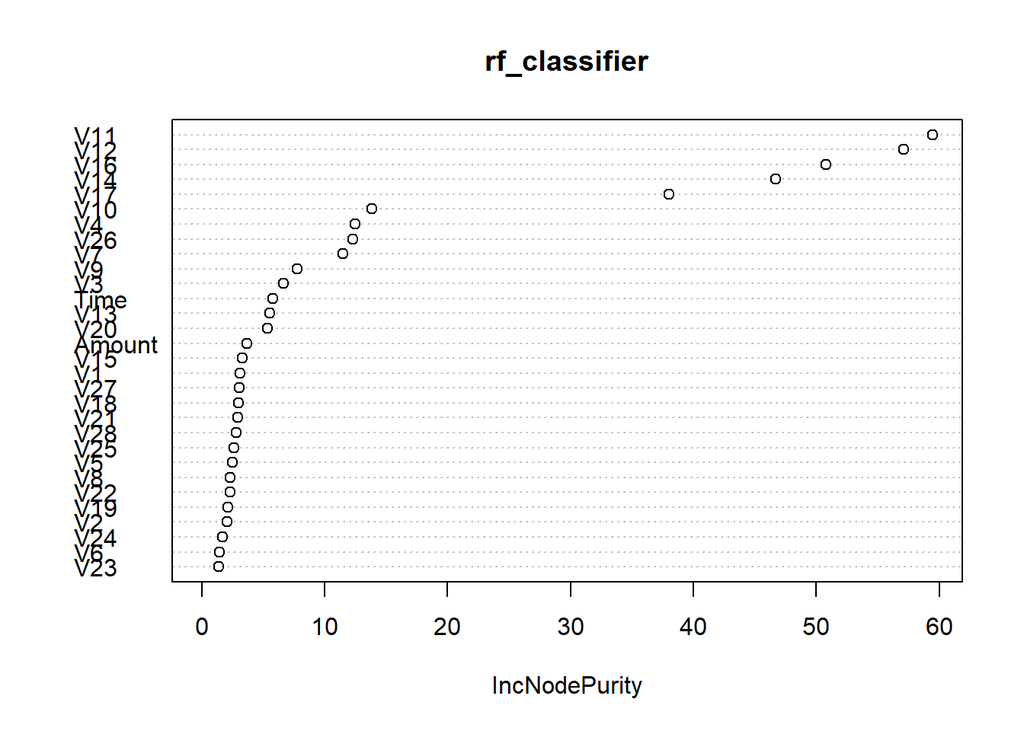

```r
varImpPlot(rf_classifier)
```

```r
rf_pred=predict(rf_classifier,newdata=test)
rf_predicted=ifelse(rf_pred>=0.5,1,0)
rf.contingency.table=table(rf_predicted,test$Class)
rf.contingency.table
```

```
##
## rf_predicted     0     1
##            0 56667    30
##            1     7    80
```

```r
rf.test.mse=mean(sum((rf_predicted-test$Class)**2))
rf.test.mse
```

```
## [1] 37
```

```r
rf.accuracy=sum(diag(rf.contingency.table))/sum(rf.contingency.table)
rf.accuracy
```

```
## [1] 0.9993484
```

**Comments:** Now, similarly I fit random forest on the train dataset and I validated the model using the test data. The test mse is less than logistic regression. The accuracy of the model come out to be 99.93%